# sonya isrib synthesis

This document details the analysis of proteomics data acquired to look at protein synthesis in isrib treated cells, plus and minus hypoxia (0h, 3h, 24h).

## Setting up the environment

These are packages you will need for this notebook. For exact versions used, please refer to the session info at the bottom of this notebook.

```r
##########################################################################################
library('tidyverse')
library('limma')
library('DEqMS')
library('RColorBrewer')
```

I want to set a base directory that we can use as a link to the directory where we will do most of the work. I use two directories here because the Workspace is what is pushed to GitHub and contains scripts and plot files, but the Repository is where more of the big data is stored that does not get pushed.

```r
##########################################################################################
generalDatasets = 'C:/Users/chughes/Documents/bccrc/projectsRepository/generalDatasets'
baseWorkspace = 'C:/Users/chughes/Documents/bccrc/projectsWorkspace/sorensenLab/relatedToOthers'
baseRepository = 'D:/msDataTemp/proteomics20201119_sonyaTranslationSet'
#generalDatasets = 'C:/Users/chris/OneDrive/Documents/bccrc/projectsRepository/generalDatasets'
#baseWorkspace = 'C:/Users/chris/OneDrive/Documents/bccrc/projectsWorkspace/sorensenLab/relatedToYbx1'
#baseRepository = 'C:/Users/chris/OneDrive/Documents/bccrc/projectsRepository/sorensenLab/relatedToYbx1'
```

## Data processing

First we can process the psm data into a single set of data.

```r
##########################################################################################
##this is the function we will use to parse the PSM data from FragPipe
combinePsmFiles = function(filePath, ...){
  psm = read_tsv(filePath) %>%
    dplyr::select(Peptide, `Protein ID`, Gene, Spectrum, `Assigned Modifications`) %>%
    dplyr::rename(sequence = Peptide,
                  accession = `Protein ID`,
                  gene = Gene,
                  scan = Spectrum,
                  mods = `Assigned Modifications`) %>%
    dplyr::mutate(fraction = sub('.*HpH_(.*)\\.[0-9]+\\.[0-9]+\\.[0-9]+','\\1',scan)) %>%
    dplyr::mutate(batch = sub('.*TranslationSet(.*)Tmd_silac10R8K-TMT10_HpH_[0-9]+\\.[0-9]+\\.[0-9]+\\.[0-9]+','\\1',scan)) %>%
    dplyr::mutate(scan = as.numeric(sub('.*HpH_[0-9]+\\.(.*)\\.[0-9]+\\.[0-9]+','\\1',scan))) %>%
    dplyr::mutate(label = ifelse(grepl('R\\(10',mods),'heavy',
                                ifelse(grepl('K\\(237',mods),'heavy','light'))) %>%
    dplyr::filter(!grepl('CONT', accession), !is.na(gene), !grepl('-', gene)) %>%
    dplyr::select(scan, batch, fraction, accession, gene, sequence, label)
  ##
  return(psm)
}

#run the function over the PSM files and combine them
psmFiles = list.files(paste(baseRepository,'/fragpipeAnalysis',sep=''),
                      pattern = 'psm.tsv', full.names = TRUE, recursive = TRUE)
psmDataSet = lapply(psmFiles, combinePsmFiles)
allPsmData = do.call('rbind', psmDataSet)
allPsmData
```

| scan | batch | fraction | accession | gene | sequence | label |
| --- | --- | --- | --- | --- | --- | --- |
| 1976 | 1 | 1 | Q8WXF1 | PSPC1 | HEEEHRR | heavy |
| 2263 | 1 | 1 | Q9P2R6 | RERE | HNENDSGR | light |
| 2264 | 1 | 1 | Q9P2R6 | RERE | HNENDSGR | heavy |
| 2365 | 1 | 1 | Q07065 | CKAP4 | SQEHEQR | light |
| 2366 | 1 | 1 | Q07065 | CKAP4 | SQEHEQR | heavy |
| 2371 | 1 | 1 | Q07065 | CKAP4 | SQEHEQR | heavy |
| 2412 | 1 | 1 | Q9BUJ2 | HNRNPUL1 | DNNNSNNR | light |
| 2413 | 1 | 1 | Q9BUJ2 | HNRNPUL1 | DNNNSNNR | heavy |
| 2544 | 1 | 1 | P12956 | XRCC6 | HDNEGSGSK | heavy |
| 2551 | 1 | 1 | P12956 | XRCC6 | HDNEGSGSK | light |

[output cut: 990 more lines]

Now we can get the quant data and process it into a single object, as above.

```r
##########################################################################################
##this is the function we will use to parse the quant data from RawTools
combineQuantFiles = function(filePath, ...){
  quantData = read_tsv(filePath) %>%
    dplyr::select(MS2ScanNumber, `126Intensity`:`131CIntensity`)
  colnames(quantData) = c('scan','tmt126C','tmt127N','tmt127C','tmt128N',
                  'tmt128C','tmt129N','tmt129C','tmt130N','tmt130C','tmt131N','tmt131C')
  ##
  fraction = sub('.*HpH_(.*)\\.raw_Matrix\\.txt', '\\1', filePath)
  batch = sub('.*TranslationSet(.*)Tmd_silac10R8K-TMT10_HpH_[0-9]+\\.raw_Matrix\\.txt', '\\1', filePath)
  quantData$fraction = fraction
  quantData$batch = batch
  print(paste('Processing file for fraction ', fraction, '.', sep = ''))
  ##
  return(quantData)
}

#run the function over the quant files and combine them
quantFiles = list.files(paste(baseRepository,'/quantFiles/',sep=''),
           pattern = '_Matrix.txt', full.names = TRUE)
quantDataSet = lapply(quantFiles, combineQuantFiles)
```

```
[1] "Processing file for fraction 1."

[1] "Processing file for fraction 10."

[1] "Processing file for fraction 11."

[1] "Processing file for fraction 12."

[1] "Processing file for fraction 13."

[1] "Processing file for fraction 14."

[1] "Processing file for fraction 15."

[1] "Processing file for fraction 16."

[1] "Processing file for fraction 17."

[1] "Processing file for fraction 18."

[1] "Processing file for fraction 19."

[1] "Processing file for fraction 2."

[1] "Processing file for fraction 20."

[1] "Processing file for fraction 21."

[1] "Processing file for fraction 22."

[1] "Processing file for fraction 23."

[1] "Processing file for fraction 24."

[1] "Processing file for fraction 25."

[1] "Processing file for fraction 26."

[1] "Processing file for fraction 27."

```

[output cut: 160 more lines]

```
[1] "Processing file for fraction 35."

[1] "Processing file for fraction 36."

[1] "Processing file for fraction 4."

[1] "Processing file for fraction 5."

[1] "Processing file for fraction 6."

[1] "Processing file for fraction 7."

[1] "Processing file for fraction 8."

[1] "Processing file for fraction 9."
```

```r
allQuantData = do.call('rbind', quantDataSet)
allQuantData
```

| scan | tmt126C | tmt127N | tmt127C | tmt128N | tmt128C | tmt129N | tmt129C | tmt130N | tmt130C | tmt131N | tmt131C | fraction | batch |
| --- | --- | --- | --- | --- | --- | --- | --- | --- | --- | --- | --- | --- | --- |
| 3 | 0.0000 | 0.0000 | 0.0000 | 0.0000 | 0.0000 | 0.0000 | 0.0000 | 0.0000 | 0.0000 | 0.0000 | 0.0000 | 1 | 1 |
| 4 | 0.0000 | 0.0000 | 0.0000 | 0.0000 | 0.0000 | 0.0000 | 0.0000 | 0.0000 | 0.0000 | 0.0000 | 0.0000 | 1 | 1 |
| 14 | 0.0000 | 0.0000 | 0.0000 | 0.0000 | 0.0000 | 0.0000 | 0.0000 | 0.0000 | 0.0000 | 0.0000 | 0.0000 | 1 | 1 |
| 15 | 0.0000 | 0.0000 | 0.0000 | 0.0000 | 0.0000 | 0.0000 | 0.0000 | 0.0000 | 0.0000 | 0.0000 | 0.0000 | 1 | 1 |
| 19 | 0.0000 | 0.0000 | 0.0000 | 0.0000 | 0.0000 | 0.0000 | 0.0000 | 0.0000 | 0.0000 | 0.0000 | 0.0000 | 1 | 1 |
| 20 | 0.0000 | 0.0000 | 0.0000 | 0.0000 | 0.0000 | 0.0000 | 0.0000 | 0.0000 | 607.2175 | 0.0000 | 0.0000 | 1 | 1 |
| 24 | 0.0000 | 0.0000 | 0.0000 | 0.0000 | 0.0000 | 0.0000 | 0.0000 | 0.0000 | 0.0000 | 0.0000 | 0.0000 | 1 | 1 |
| 25 | 0.0000 | 0.0000 | 0.0000 | 0.0000 | 0.0000 | 0.0000 | 0.0000 | 0.0000 | 0.0000 | 0.0000 | 0.0000 | 1 | 1 |
| 29 | 0.0000 | 0.0000 | 0.0000 | 0.0000 | 0.0000 | 0.0000 | 0.0000 | 0.0000 | 0.0000 | 0.0000 | 0.0000 | 1 | 1 |
| 30 | 0.0000 | 0.0000 | 0.0000 | 0.0000 | 0.0000 | 0.0000 | 0.0000 | 0.0000 | 0.0000 | 0.0000 | 0.0000 | 1 | 1 |

[output cut: 990 more lines]

Now combine the data.

```r
##########################################################################################
combinedData = allPsmData %>%
  left_join(allQuantData)
##
saveRDS(combinedData, paste(baseRepository, '/dataset_processedIdAndQuantPsmData.rds', sep=''))
```

From the original mePROD paper:

Excel files were used as input for a custom made in-house Python pipeline. Python 3.6 was used together with the following packages: pandas 0.23.4 (McKinney, 2010), numpy 1.15.4 (van der Walt et al., 2011), matplotlib 3.0.1 (Hunter, 2007). Excel files with peptide data were read in and each channel was normalized to the lowest channel based on total intensity. For each peptide sequence, all possible modification states containing a heavy label were extracted and the intensities for each channel were averaged between all modified peptides. Baseline subtraction was performed by subtracting the measured intensities for the non-SILAC-labeled sample from all other values. Negative intensities were treated as zero. For relative quantification, channel values were divided by the abundance in the booster channel. The heavy label incorporation at the protein level was calculated by taking the median of all peptide sequences belonging to one unique protein accession. These values were combined with the standard protein output of PD 2.2 to add annotation data to the master protein accessions.

Log2 fold changes were calculated by log2 transformation of the ratio between the mean of the replicates of treated samples versus the control samples. Significance was assessed by unpaired, two-sided Student’s t test. P values were adjusted by Benjamini-Hochberg FDR correction. Adjusted P values lower than 0.05 were considered as significant. N represents number of independent replicates. Error bars, unless stated otherwise, indicate the standard deviation of replicates. Unless stated otherwise significance was defined as adjusted P values < 0.05. Adjusted P value and fold change cutoffs were applied as indicated. For clustering and enrichment analyses (see below) q value cutoffs of 0.001 were used for significance definition. Plotting and fitting of data was performed with Origin Pro 2018. For linear regression P values were calculated with Origin and raw P-values used for statistics

We can try it this way. Before I do this, I want to add some checks so we can look at pre- and post-data scaling.

Our sample layout is:

- 126C - dmso1
- 127N - isrib1
- 127C - dmso2
- 128N - isrib2
- 128C - dmso3
- 129N - isrib3
- 129C - empty
- 130N - empty
- 130C - heavySpike1
- 131N - lightSpike
- 131C - heavySpike2

Set1 is 0h, Set2 is 3h, Set3 is 24h of hypoxia. The first thing we will do here is to compare the batches (at the peptide level) to see if there are any big differences in the signal between samples (e.g. loading differences).

```r
##########################################################################################
#read in our peptide data created above
psmData = readRDS(paste(baseRepository, '/dataset_processedIdAndQuantPsmData.rds', sep=''))

#this is our TMT layout for the different sets
tmtBatch = tibble('batch1' = c('dmso1_0h','isrib1_0h','dmso2_0h','isrib2_0h','dmso3_0h','isrib3_0h','boostMix1_0h','lightMix1_0h','boostMix2_0h'),
                  'batch2' = c('dmso1_3h','isrib1_3h','dmso2_3h','isrib2_3h','dmso3_3h','isrib3_3h','boostMix1_3h','lightMix1_3h','boostMix2_3h'),
                  'batch3' = c('dmso1_24h','isrib1_24h','dmso2_24h','isrib2_24h','dmso3_24h','isrib3_24h','boostMix1_24h','lightMix1_24h','boostMix2_24h'))


#plot signal in the different batches for light peptides
exp1Light = psmData[psmData$batch == 1 & psmData$label == 'light', c(8:13,16:18)]
colnames(exp1Light) = tmtBatch$batch1
dim(exp1Light)
```

```
[1] 81424     9
```

```r
exp2Light = psmData[psmData$batch == 2 & psmData$label == 'light', c(8:13,16:18)]
colnames(exp2Light) = tmtBatch$batch2
dim(exp2Light)
```

```
[1] 77119     9
```

```r
exp3Light = psmData[psmData$batch == 3 & psmData$label == 'light', c(8:13,16:18)]
colnames(exp3Light) = tmtBatch$batch3
dim(exp3Light)
```

```
[1] 77101     9
```

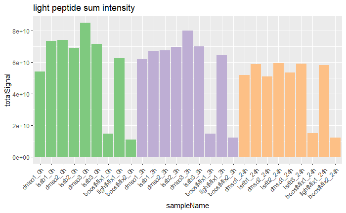

```r
allLight = c(colSums(exp1Light,na.rm = TRUE),colSums(exp2Light,na.rm = TRUE),colSums(exp3Light,na.rm = TRUE))
allLightPlot = tibble('sampleName' = factor(names(allLight),levels = names(allLight)), 'totalSignal' = allLight)
ggplot(allLightPlot, aes(sampleName, totalSignal, fill = sampleName)) +
  geom_bar(stat = 'identity') +
  labs(title = 'light peptide sum intensity') +
  scale_fill_manual(values = c(rep(brewer.pal(3,'Accent'),each = 9))) +
  theme(legend.position = 'none',
        axis.text.x = element_text(angle = 45, hjust = 1))
```

```r
#plot signal in the different batches for heavy peptides
exp1Heavy = psmData[psmData$batch == 1 & psmData$label == 'heavy', c(8:13,16:18)]
colnames(exp1Heavy) = tmtBatch$batch1
dim(exp1Heavy)
```

```
[1] 59804     9
```

```r
exp2Heavy = psmData[psmData$batch == 2 & psmData$label == 'heavy', c(8:13,16:18)]
colnames(exp2Heavy) = tmtBatch$batch2
dim(exp2Heavy)
```

```
[1] 56115     9
```

```r
exp3Heavy = psmData[psmData$batch == 3 & psmData$label == 'heavy', c(8:13,16:18)]
colnames(exp3Heavy) = tmtBatch$batch3
dim(exp3Heavy)
```

```
[1] 58196     9
```

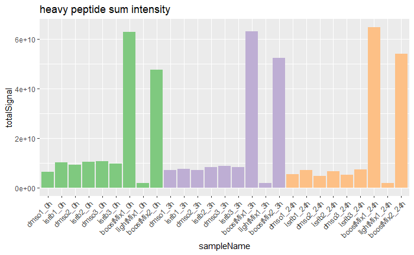

```r
allHeavy = c(colSums(exp1Heavy,na.rm = TRUE),colSums(exp2Heavy,na.rm = TRUE),colSums(exp3Heavy,na.rm = TRUE))
allHeavyPlot = tibble('sampleName' = factor(names(allHeavy),levels = names(allHeavy)), 'totalSignal' = allHeavy)
ggplot(allHeavyPlot, aes(sampleName, totalSignal, fill = sampleName)) +
  geom_bar(stat = 'identity') +
  labs(title = 'heavy peptide sum intensity') +
  scale_fill_manual(values = c(rep(brewer.pal(3,'Accent'),each = 9))) +
  theme(legend.position = 'none',
        axis.text.x = element_text(angle = 45, hjust = 1))
```

```r
#plot signal in the different batches for all peptides
exp1 = psmData[psmData$batch == 1, c(8:13,16:18)]
colnames(exp1) = tmtBatch$batch1
dim(exp1)
```

```
[1] 141228      9
```

```r
exp2 = psmData[psmData$batch == 2, c(8:13,16:18)]
colnames(exp2) = tmtBatch$batch2
dim(exp2)
```

```
[1] 133234      9
```

```r
exp3 = psmData[psmData$batch == 3, c(8:13,16:18)]
colnames(exp3) = tmtBatch$batch3
dim(exp3)
```

```
[1] 135297      9
```

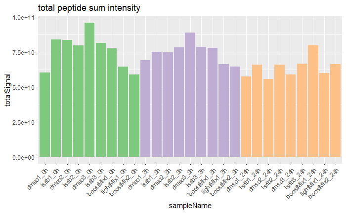

```r
allPeps = c(colSums(exp1,na.rm = TRUE),colSums(exp2,na.rm = TRUE),colSums(exp3,na.rm = TRUE))
allPepsPlot = tibble('sampleName' = factor(names(allPeps),levels = names(allPeps)), 'totalSignal' = allPeps)
ggplot(allPepsPlot, aes(sampleName, totalSignal, fill = sampleName)) +
  geom_bar(stat = 'identity') +
  labs(title = 'total peptide sum intensity') +
  scale_fill_manual(values = c(rep(brewer.pal(3,'Accent'),each = 9))) +
  theme(legend.position = 'none',
        axis.text.x = element_text(angle = 45, hjust = 1))
```

So there are some small differences (aside from the booster). I think it is generally OK, but we will normalize the data based on the sum total intensity between the samples. This includes light and heavy. For the heavy peptides we definitely expect there should be some biological difference between the sets which we don’t want to get rid of. But, when you have both light and heavy peptide signal, the heavy signal is comparatively negligible. We don’t really expect there to be a big difference between the light + heavy signal unless there was a loading difference, so this is why we include both in this calculation.

```r
##########################################################################################
#mePROD - 'each channel was normalized to the lowest channel based on total intensity'
#I think this means they calculate the total intensity for each channel and scale them so that they hit the same total
psmData = readRDS(paste(baseRepository, '/dataset_processedIdAndQuantPsmData.rds', sep=''))

#batch 1
exp1Raw = psmData[psmData$batch == 1, c(8:13,16:18)]
target = min(colSums(exp1Raw, na.rm = TRUE))
target
```

```
[1] 58720618139
```

```r
normFacs = target / colSums(exp1Raw, na.rm = TRUE)
exp1Sl = sweep(exp1Raw, 2, normFacs, FUN = "*")

#batch 2
exp2Raw = psmData[psmData$batch == 2, c(8:13,16:18)]
target = min(colSums(exp2Raw, na.rm = TRUE))
target
```

```
[1] 64479250000
```

```r
normFacs = target / colSums(exp2Raw, na.rm = TRUE)
exp2Sl = sweep(exp2Raw, 2, normFacs, FUN = "*")

#batch 3
exp3Raw = psmData[psmData$batch == 3, c(8:13,16:18)]
target = min(colSums(exp3Raw, na.rm = TRUE))
target
```

```
[1] 55762973829
```

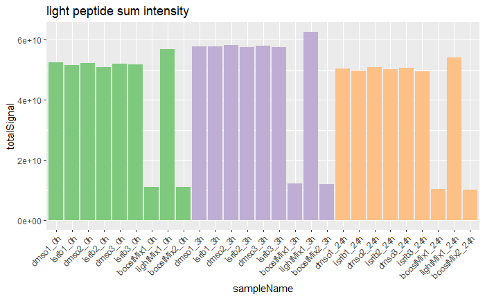

```r
normFacs = target / colSums(exp3Raw, na.rm = TRUE)
exp3Sl = sweep(exp3Raw, 2, normFacs, FUN = "*")

#combine
allExp = rbind(exp1Sl, exp2Sl, exp3Sl)
psmData[,c(8:13,16:18)] = allExp


#quality check, light
lightExp1 = psmData[psmData$batch == 1 & psmData$label == 'light', c(8:13,16:18)]
lightExp2 = psmData[psmData$batch == 2 & psmData$label == 'light', c(8:13,16:18)]
lightExp3 = psmData[psmData$batch == 3 & psmData$label == 'light', c(8:13,16:18)]
allLight = c(colSums(lightExp1,na.rm = TRUE),colSums(lightExp2,na.rm = TRUE),colSums(lightExp3,na.rm = TRUE))
names(allLight) = c(tmtBatch$batch1, tmtBatch$batch2, tmtBatch$batch3)
allLightPlot = tibble('sampleName' = factor(names(allLight),levels = names(allLight)), 'totalSignal' = allLight)
ggplot(allLightPlot, aes(sampleName, totalSignal, fill = sampleName)) +
  geom_bar(stat = 'identity') +
  labs(title = 'light peptide sum intensity') +
  scale_fill_manual(values = c(rep(brewer.pal(3,'Accent'),each = 9))) +
  theme(legend.position = 'none',
        axis.text.x = element_text(angle = 45, hjust = 1))
```

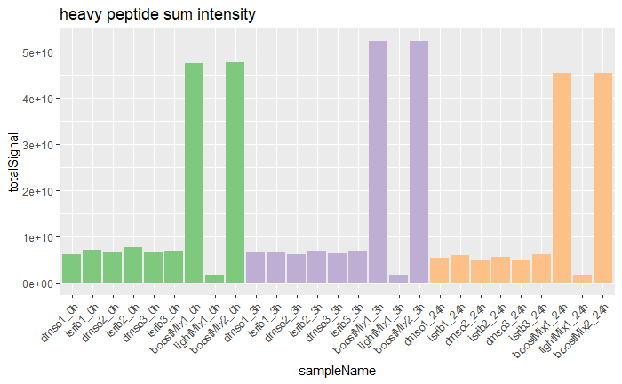

```r
#quality check, heavy
heavyExp1 = psmData[psmData$batch == 1 & psmData$label == 'heavy', c(8:13,16:18)]
heavyExp2 = psmData[psmData$batch == 2 & psmData$label == 'heavy', c(8:13,16:18)]
heavyExp3 = psmData[psmData$batch == 3 & psmData$label == 'heavy', c(8:13,16:18)]
allHeavy = c(colSums(heavyExp1,na.rm = TRUE),colSums(heavyExp2,na.rm = TRUE),colSums(heavyExp3,na.rm = TRUE))
names(allHeavy) = c(tmtBatch$batch1, tmtBatch$batch2, tmtBatch$batch3)
allHeavyPlot = tibble('sampleName' = factor(names(allHeavy),levels = names(allHeavy)), 'totalSignal' = allHeavy)
ggplot(allHeavyPlot, aes(sampleName, totalSignal, fill = sampleName)) +
  geom_bar(stat = 'identity') +
  labs(title = 'heavy peptide sum intensity') +
  scale_fill_manual(values = c(rep(brewer.pal(3,'Accent'),each = 9))) +
  theme(legend.position = 'none',
        axis.text.x = element_text(angle = 45, hjust = 1))
```

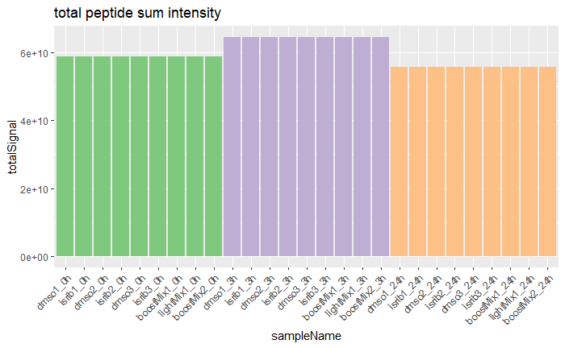

```r
#quality check, total
allExp1 = psmData[psmData$batch == 1, c(8:13,16:18)]
allExp2 = psmData[psmData$batch == 2, c(8:13,16:18)]
allExp3 = psmData[psmData$batch == 3, c(8:13,16:18)]
allPeps = c(colSums(allExp1,na.rm = TRUE),colSums(allExp2,na.rm = TRUE),colSums(allExp3,na.rm = TRUE))
names(allPeps) = c(tmtBatch$batch1, tmtBatch$batch2, tmtBatch$batch3)
allPepsPlot = tibble('sampleName' = factor(names(allPeps),levels = names(allPeps)), 'totalSignal' = allPeps)
ggplot(allPepsPlot, aes(sampleName, totalSignal, fill = sampleName)) +
  geom_bar(stat = 'identity') +
  labs(title = 'total peptide sum intensity') +
  scale_fill_manual(values = c(rep(brewer.pal(3,'Accent'),each = 9))) +
  theme(legend.position = 'none',
        axis.text.x = element_text(angle = 45, hjust = 1))
```

Next step in their procedure is to subtract any signal that is in the ‘light’ SILAC channel, which is presumably noise.

```r
##########################################################################################
#For each peptide sequence, all possible modification states containing a heavy label were extracted and the intensities for each channel were averaged between all modified #peptides. Baseline subtraction was performed by subtracting the measured intensities for the non-SILAC-labeled sample from all other values. Negative intensities were #treated as zero.

#filter for heavy peptides and collapse multiple PSMs for the same peptide sequence, taking the mean of tmt intensities
pepData = psmData %>%
  dplyr::filter(grepl('heavy', label)) %>%
  dplyr::group_by(batch,accession,gene,sequence) %>%
  dplyr::summarise(across(tmt126C:tmt131C, mean, na.rm = TRUE))
#subtract the tmt131N (light SILAC) channel from the others and change negative values to 0
pepDataBaseline = apply(pepData[,c(5:10,13:15)], 2, function(x) x - pepData$tmt131N)
pepDataBaseline[pepDataBaseline < 0] = 0

#recombine
pepDataFinal = pepData
pepDataFinal[,c(5:10,13:15)] = pepDataBaseline
```

Next step in their procedure is to scale the data against the booster channel. In our case we have two boosters. We could use the mean/median of them, or just use one or the other. I opted to use just the 131C version as it should be mostly free from any other interference.

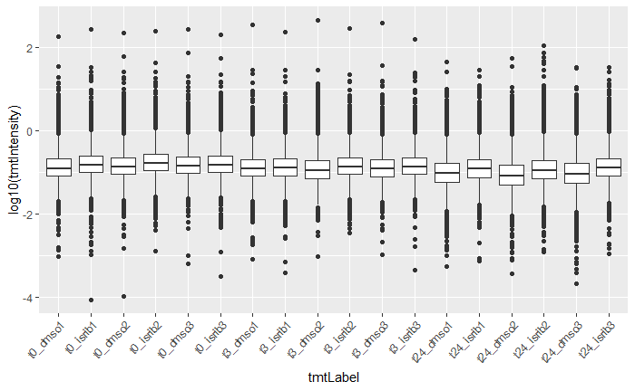

```r
##########################################################################################
#For relative quantification, channel values were divided by the abundance in the booster channel. The heavy label incorporation at the protein level was calculated by
#taking the median of all peptide sequences belonging to one unique protein accession.

#divide by the booster channel
boosterScale = apply(pepDataFinal[,c(5:10)], 2, function(x) x / pepDataFinal$tmt131C)
pepDataBooster = pepDataFinal
pepDataBooster[,c(5:10)] = boosterScale

#roll up into proteins
proData = pepDataBooster %>%
  dplyr::select(-tmt129C, -tmt130N, -tmt131N, -tmt131C) %>%
  dplyr::group_by(batch, accession, gene) %>%
  dplyr::summarise(across(tmt126C:tmt129N, median, na.rm = TRUE))
#reshape the data into the different batches
tmtBatch = tibble('batch1' = c('t0_dmso1','t0_isrib1','t0_dmso2','t0_isrib2','t0_dmso3','t0_isrib3'),
                  'batch2' = c('t3_dmso1','t3_isrib1','t3_dmso2','t3_isrib2','t3_dmso3','t3_isrib3'),
                  'batch3' = c('t24_dmso1','t24_isrib1','t24_dmso2','t24_isrib2','t24_dmso3','t24_isrib3'))

##now reshape the data to combine the different batches
proBatches = proData %>%
  tidyr::pivot_longer(cols = tmt126C:tmt129N, names_to = 'tmtLabel', values_to = 'tmtIntensity') %>%
  tidyr::pivot_wider(names_from = c(tmtLabel, batch), values_from = tmtIntensity)
colnames(proBatches)[3:20] = c(tmtBatch$batch1, tmtBatch$batch2, tmtBatch$batch3)

##plot the different batches to see how this looks at the protein level
ptxPlot = proBatches %>%
  pivot_longer(cols = t0_dmso1:t24_isrib3, names_to = 'tmtLabel', values_to = 'tmtIntensity') %>%
  dplyr::mutate(tmtLabel = factor(tmtLabel, levels = colnames(proBatches)[3:20]))
ggplot(ptxPlot, aes(tmtLabel, log10(tmtIntensity))) +
  geom_boxplot() +
  theme(axis.text.x = element_text(angle = 45, hjust = 1))
```

Next step in their procedure is to perform a t-test between conditions. In the code below you can change the values for conditionOne and conditionTwo to be the two sets you want to compare (e.g. t3_dmso, don’t include the replicate number, it will pull out all 3 of them).

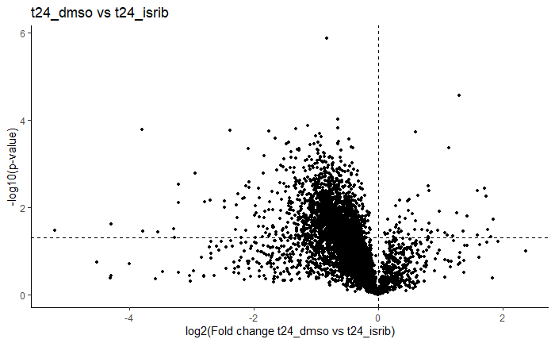

```r
##########################################################################################
##the code below will perform a t-test comparing two conditions
#change these values to alter the conditions you want to compare
conditionOne = 't24_dmso'
conditionTwo = 't24_isrib'
testData = proBatches %>%
  dplyr::select(accession, gene, which(grepl(conditionOne, colnames(proBatches))), which(grepl(conditionTwo, colnames(proBatches))))


#perform some filtering of the data to remove samples with too many NA values
is.na(testData) = sapply(testData, is.infinite)
testData[is.na(testData)] = 0
testData[testData == 0] = NA
testDataSub = subset(testData, rowSums(is.na(testData[3:5]))<2 & rowSums(is.na(testData[6:8]))<2)


#calculate fold change and p-values
pvalSet = apply(testDataSub, 1, function(x) t.test(as.numeric(x[c(3:5)]), as.numeric(x[c(6:8)]))$p.value)
logFcSet = log2(rowMeans(testDataSub[,c(3:5)],na.rm = TRUE) / rowMeans(testDataSub[,c(6:8)],na.rm = TRUE))
testResults = tibble(gene = testDataSub$gene,
                    logFc = logFcSet,
                    pValue = pvalSet,
                    pValueAdj = p.adjust(pvalSet, method = "BH"))


#plot the result
ggplot(testResults, aes(logFc, -log10(pValue))) +
  geom_point(size = 1) +
  labs(x = paste('log2(Fold change ', conditionOne, ' vs ', conditionTwo,')',sep=''),
       y = '-log10(p-value)',
       title = paste(conditionOne, ' vs ', conditionTwo, sep = '')) +
  geom_vline(xintercept = 0, linetype = 'dashed') +
  geom_hline(yintercept = -log10(0.05), linetype = 'dashed') +
  theme_classic()
```

```r
#write the result to a file
write.table(testResults, paste(baseRepository, '/dataset_', conditionOne, '-', conditionTwo, '.tsv', sep = ''),
            col.names = TRUE, row.names = FALSE, quote = FALSE, sep = '\t')
```

Finished. Just wrap up.

[session information not shown]